# Assignment 2 Task 1 - Binary Logistic Regression (individual

Matthieu Huy

2023-02-08

```r
knitr::opts_chunk$set(echo = TRUE, warning = FALSE, message = FALSE)
library(tidyverse)
library(tidymodels)
library(kableExtra)
library(here)
library(cowplot)
library(GGally)
library(AICcmodavg)
library(jtools)
```

The data used in this analysis, collected at Archbold Biological Station in south-central Florida from 1981 to 2017, measures the survival, growth, and biomass of two dominant palmetto tree species, Serenoa repens and Sabal etonia, collected at Archbold Biological Station in south-central Florida from 1981 to 2017. This data also records the height, canopy length and width, number of new and green leaves, and flowering scapes.

Citation:  
- Abrahamson, W.G. 2019. Survival, growth and biomass estimates of two dominant palmetto species of south-central Florida from 1981 - 2017, ongoing at 5-year intervals ver 1. Environmental Data Initiative. https://doi.org/10.6073/pasta/f2f96ec76fbbd4b9db431c79a770c4d5\ (Accessed 2023-02-08).

Metadata:  
- https://portal.edirepository.org/nis/metadataviewer?packageid=edi.317.1

For this analysis, I will compare two binary logistic regression models using 10-fold cross-validation to determine the probability of a plant being of either species based on several predictor variables.

- Model 1: Log odds of plant type using plant height, canopy length, canopy width, and green leaves as predictor variables.
- Model 2: Log odds of plant type using plant height, canopy width, and green leaves as predictor variables (dropping canopy length).

### Read in and clean data

```r
palmetto_data <- read.csv(here("data/palmetto.csv")) |>
  select(species, survival, height, canopy_length = length, canopy_width = width, green_lvs) |>
  mutate_at(vars(1:2), as.factor) |> #change species and survival columns to factor levels
  filter(survival == 1) |> #select only the trees marked "alive", removing dead and missing trees
  select(-survival) |>
  mutate_at(vars(2:5), as.numeric) #change height, length, width, and leaves columns to numeric

levels(palmetto_data$species) <- c("Serenoa repens", "Sabal etonia")
#shows species "1" - Serenoa repens - is the reference level 0
```

### Data visualization

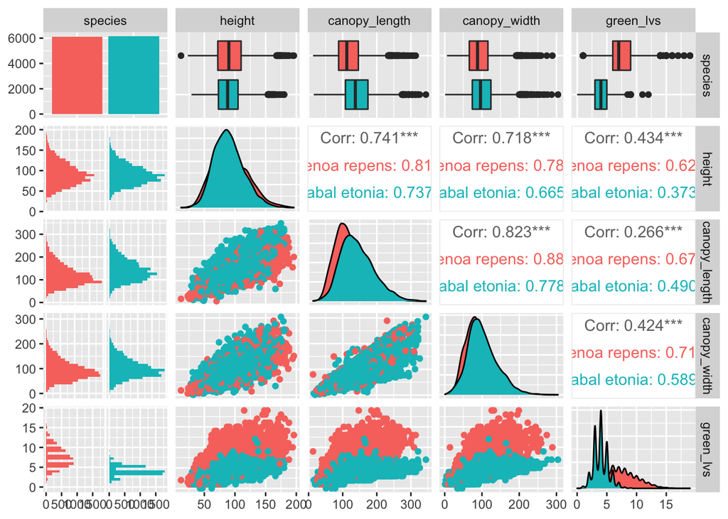

```r
GGally::ggpairs(palmetto_data |> #takes all variables in data set and generates grid of plots
                select(species, height:green_lvs),
                aes(color = species))
```

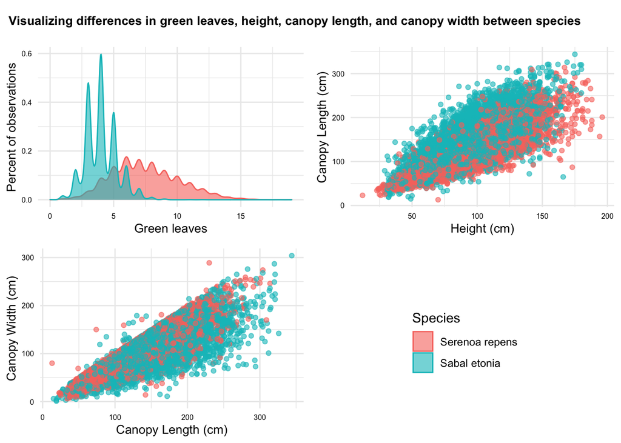

```r
plot1 <- ggplot() +
  geom_density(data = palmetto_data,
               aes(x = green_lvs,
                   fill = species,
                   color = species),
               alpha = 0.6) +
  theme_minimal() +
  labs(x = "Green leaves",
       y = "Percent of observations",
       fill = "Species",
       color = "Species") +
  theme(axis.text = element_text(color = "black", size = 6),                    #fonts/font sizes
        axis.title.x = element_text(color = "black", size = 10),
        axis.title.y = element_text(color = "black", size = 10))

legend <- get_legend(plot1) #extract legend

plot1 <- plot1 +
  theme(legend.position = "none")

plot2 <- ggplot() +
  geom_point(data = palmetto_data,
             aes(x = height,
                 y = canopy_length,
                 color = species),
             alpha = 0.6) +
  theme_minimal() +
  labs(x = "Height (cm)",
       y = "Canopy Length (cm)",
       color = "Species") +
  theme(axis.text = element_text(color = "black", size = 6),                    #fonts/font sizes
        axis.title.x = element_text(color = "black", size = 10),
        axis.title.y = element_text(color = "black", size = 10),
        legend.position = "none")

plot3 <- ggplot() +
  geom_point(data = palmetto_data,
             aes(x = canopy_length,
                 y = canopy_width,
                 color = species),
             alpha = 0.6) +
  theme_minimal() +
  labs(x = "Canopy Length (cm)",
       y = "Canopy Width (cm)",
       color = "Species") +
  theme(axis.text = element_text(color = "black", size = 6),                    #fonts/font sizes
        axis.title.x = element_text(color = "black", size = 10),
        axis.title.y = element_text(color = "black", size = 10),
        legend.position = "none")

#create title
title <- ggdraw() +
  draw_label(
    "Visualizing differences in green leaves, height, canopy length, and canopy width between species",
    fontface = 'bold',
    size = 10,
    x = 0,
    hjust = 0
  ) +
  theme(
    # add margin on the left of the drawing canvas,
    # so title is aligned with left edge of first plot
    plot.margin = margin(0, 0, 0, 7)
  )


plots <- plot_grid(plot1, plot2, plot3, legend)

plot_grid(title, plots,
          ncol = 1,
  # rel_heights values control vertical title margins
          rel_heights = c(0.1, 1))
```

As shown in the top-left plot, there appears to be a significant difference in green leaves between the two species, with most Sabal etonia trees concentrated in the <5 range, and Serenoa repens trees more broadly spread but mostly in the >5 range. Both species seem to have a similar distribution of heights and canopy widths, and there appears to be small differences canopy length, with more observations of Sabal etonia with large canopy lengths. Based on these plots, green leaves and canopy length are likely to serve as the best predictor variables to help classify species.